# Machine Learning Engineer Nanodegree

## Model Evaluation & Validation

## Project: Predicting Boston Housing Prices

Welcome to the first project of the Machine Learning Engineer Nanodegree! In this notebook, some template code has already been provided for you, and you will need to implement additional functionality to successfully complete this project. You will not need to modify the included code beyond what is requested. Sections that begin with **'Implementation'** in the header indicate that the following block of code will require additional functionality which you must provide. Instructions will be provided for each section and the specifics of the implementation are marked in the code block with a 'TODO' statement. Please be sure to read the instructions carefully!

In addition to implementing code, there will be questions that you must answer which relate to the project and your implementation. Each section where you will answer a question is preceded by a **'Question X'** header. Carefully read each question and provide thorough answers in the following text boxes that begin with **'Answer:'**. Your project submission will be evaluated based on your answers to each of the questions and the implementation you provide.

> **Note:** Code and Markdown cells can be executed using the **Shift + Enter** keyboard shortcut. In addition, Markdown cells can be edited by typically double-clicking the cell to enter edit mode.

## Getting Started

In this project, you will evaluate the performance and predictive power of a model that has been trained and tested on data collected from homes in suburbs of Boston, Massachusetts. A model trained on this data that is seen as a *good fit* could then be used to make certain predictions about a home — in particular, its monetary value. This model would prove to be invaluable for someone like a real estate agent who could make use of such information on a daily basis.

The dataset for this project originates from the [UCI Machine Learning Repository](https://archive.ics.uci.edu/ml/datasets/Housing). The Boston housing data was collected in 1978 and each of the 506 entries represent aggregated data about 14 features for homes from various suburbs in Boston, Massachusetts. For the purposes of this project, the following preprocessing steps have been made to the dataset:

- 16 data points have an `'MEDV'` value of 50.0. These data points likely contain **missing or censored values** and have been removed.
- 1 data point has an `'RM'` value of 8.78. This data point can be considered an **outlier** and has been removed.
- The features `'RM'`, `'LSTAT'`, `'PTRATIO'`, and `'MEDV'` are essential. The remaining **non-relevant features** have been excluded.
- The feature `'MEDV'` has been **multiplicatively scaled** to account for 35 years of market inflation.

Run the code cell below to load the Boston housing dataset, along with a few of the necessary Python libraries required for this project. You will know the dataset loaded successfully if the size of the dataset is reported.

```python
# Import libraries necessary for this project
import numpy as np
import pandas as pd
from sklearn.cross_validation import ShuffleSplit

# Import supplementary visualizations code visuals.py
import visuals as vs

# Pretty display for notebooks
%matplotlib inline

# Load the Boston housing dataset
data = pd.read_csv('housing.csv')
prices = data['MEDV']
features = data.drop('MEDV', axis = 1)

# Success
print "Boston housing dataset has {} data points with {} variables each.".format(*data.shape)
```

```
Boston housing dataset has 489 data points with 4 variables each.
```

## Data Exploration

In this first section of this project, you will make a cursory investigation about the Boston housing data and provide your observations. Familiarizing yourself with the data through an explorative process is a fundamental practice to help you better understand and justify your results.

Since the main goal of this project is to construct a working model which has the capability of predicting the value of houses, we will need to separate the dataset into **features** and the **target variable**. The **features**, `'RM'`, `'LSTAT'`, and `'PTRATIO'`, give us quantitative information about each data point. The **target variable**, `'MEDV'`, will be the variable we seek to predict. These are stored in `features` and `prices`, respectively.

### Implementation: Calculate Statistics

For your very first coding implementation, you will calculate descriptive statistics about the Boston housing prices. Since `numpy` has already been imported for you, use this library to perform the necessary calculations. These statistics will be extremely important later on to analyze various prediction results from the constructed model.

In the code cell below, you will need to implement the following:

- Calculate the minimum, maximum, mean, median, and standard deviation of `'MEDV'`, which is stored in `prices`.
  - Store each calculation in their respective variable.

```python
## NB: Based on first review feedback I have added additional code to check calculating statistics with both numpy and pandas.
##     I have commented out the additional code and remaining lines just use numpy to calculate statistics as required
##     by the original question

# TODO: Minimum price of the data
#minimum_price_pd = prices.min()        #calculate statistic with pandas
minimum_price = np.min(prices)          #calculate statistic with numpy
#print minimum_price_pd, minimum_price  #print both to compare

# TODO: Maximum price of the data
#maximum_price_pd = prices.max()
maximum_price = np.max(prices)
#print maximum_price_pd, maximum_price

# TODO: Mean price of the data
#mean_price_pd = prices.mean()
mean_price = np.mean(prices)
#print mean_price_pd, mean_price


# TODO: Median price of the data
#median_price_pd = prices.median()
median_price = np.median(prices)
#print median_price_pd, median_price

# TODO: Standard deviation of prices of the data
#std_price_pd = prices.std()
std_price = np.std(prices)
#print std_price_pd, std_price

# Show the calculated statistics
print "Statistics for Boston housing dataset:\n"
print "Minimum price: ${:,.2f}".format(minimum_price)
print "Maximum price: ${:,.2f}".format(maximum_price)
print "Mean price: ${:,.2f}".format(mean_price)
print "Median price ${:,.2f}".format(median_price)
print "Standard deviation of prices: ${:,.2f}".format(std_price)
```

```
Statistics for Boston housing dataset:

Minimum price: $105,000.00
Maximum price: $1,024,800.00
Mean price: $454,342.94
Median price $438,900.00
Standard deviation of prices: $165,171.13
```

### Question 1 - Feature Observation

As a reminder, we are using three features from the Boston housing dataset: `'RM'`, `'LSTAT'`, and `'PTRATIO'`. For each data point (neighborhood):

- `'RM'` is the average number of rooms among homes in the neighborhood.
- `'LSTAT'` is the percentage of homeowners in the neighborhood considered "lower class" (working poor).
- `'PTRATIO'` is the ratio of students to teachers in primary and secondary schools in the neighborhood.

*Using your intuition, for each of the three features above, do you think that an increase in the value of that feature would lead to an **increase** in the value of `'MEDV'` or a **decrease** in the value of `'MEDV'`? Justify your answer for each.*  
**Hint:** Would you expect a home that has an `'RM'` value of 6 be worth more or less than a home that has an `'RM'` value of 7?

**Answer:** For an *increase* in RM I expect the value of MEDV to *increase*. The more rooms a house has, the bigger it will generally be and so in general should be worth more money.

For an *increase* in LSTAT I would expect the value of MEDV to *decrease*. 'Lower class' people would generally have less income and hence be unable to afford expensive homes. Therefore if there are a lot of lower class people in an area it is safe to assume the average house price should be less.

For an *increase* in PTRATIO I would expect the value of MEDV to *decrease*. The higher this ratio the less attention teachers can give to each pupil and so we may expect to see a decline in overall teaching quality and results at the school. Homes tend to be more expensive if they are located close to good schools, so in this case we see the opposite affect of lower house prices.

I would expect a home that has an RM value of 6 to be worth less than a home that has an RM value of 7.

## Developing a Model

In this second section of the project, you will develop the tools and techniques necessary for a model to make a prediction. Being able to make accurate evaluations of each model's performance through the use of these tools and techniques helps to greatly reinforce the confidence in your predictions.

### Implementation: Define a Performance Metric

It is difficult to measure the quality of a given model without quantifying its performance over training and testing. This is typically done using some type of performance metric, whether it is through calculating some type of error, the goodness of fit, or some other useful measurement. For this project, you will be calculating the [*coefficient of determination*](http://stattrek.com/statistics/dictionary.aspx?definition=coefficient_of_determination), R<sup>2</sup>, to quantify your model's performance. The coefficient of determination for a model is a useful statistic in regression analysis, as it often describes how "good" that model is at making predictions.

The values for R<sup>2</sup> range from 0 to 1, which captures the percentage of squared correlation between the predicted and actual values of the **target variable**. A model with an R<sup>2</sup> of 0 is no better than a model that always predicts the *mean* of the target variable, whereas a model with an R<sup>2</sup> of 1 perfectly predicts the target variable. Any value between 0 and 1 indicates what percentage of the target variable, using this model, can be explained by the **features**. *A model can be given a negative R<sup>2</sup> as well, which indicates that the model is **arbitrarily worse** than one that always predicts the mean of the target variable.*

For the `performance_metric` function in the code cell below, you will need to implement the following:

- Use `r2_score` from `sklearn.metrics` to perform a performance calculation between `y_true` and `y_predict`.
- Assign the performance score to the `score` variable.

```python
# TODO: Import 'r2_score'
from sklearn.metrics import r2_score

def performance_metric(y_true, y_predict):
    """ Calculates and returns the performance score between
        true and predicted values based on the metric chosen. """

    # TODO: Calculate the performance score between 'y_true' and 'y_predict'
    score = r2_score(y_true, y_predict)

    # Return the score
    return score
```

### Question 2 - Goodness of Fit

Assume that a dataset contains five data points and a model made the following predictions for the target variable:

| True Value | Prediction |
| --- | --- |
| 3.0 | 2.5 |
| -0.5 | 0.0 |
| 2.0 | 2.1 |
| 7.0 | 7.8 |
| 4.2 | 5.3 |

*Would you consider this model to have successfully captured the variation of the target variable? Why or why not?*

Run the code cell below to use the `performance_metric` function and calculate this model's coefficient of determination.

```python
# Calculate the performance of this model
score = performance_metric([3, -0.5, 2, 7, 4.2], [2.5, 0.0, 2.1, 7.8, 5.3])
print "Model has a coefficient of determination, R^2, of {:.3f}.".format(score)
```

```
Model has a coefficient of determination, R^2, of 0.923.
```

**Answer:** Initially examining the data by eye, qualitatively speaking we can see that as the True Value increases so does Prediction, so it seems possible the model could be working correctly.

Quantatively speaking, we can see from the R^2 score of 0.923 that indeed the model does do a very good job of modelling the data. The R^2 score is a little less than 1 so it's not perfect, but with real-life data it is unreasonable to expect 100% accuracy. So in this case we can conclude the model is successfully capturing the variation of the target variable.

### Implementation: Shuffle and Split Data

Your next implementation requires that you take the Boston housing dataset and split the data into training and testing subsets. Typically, the data is also shuffled into a random order when creating the training and testing subsets to remove any bias in the ordering of the dataset.

For the code cell below, you will need to implement the following:

- Use `train_test_split` from `sklearn.cross_validation` to shuffle and split the `features` and `prices` data into training and testing sets.
  - Split the data into 80% training and 20% testing.
  - Set the `random_state` for `train_test_split` to a value of your choice. This ensures results are consistent.
- Assign the train and testing splits to `X_train`, `X_test`, `y_train`, and `y_test`.

```python
# TODO: Import 'train_test_split'
from sklearn.cross_validation import train_test_split

# TODO: Shuffle and split the data into training and testing subsets
X_train, X_test, y_train, y_test = train_test_split(features, prices, test_size = 0.2, random_state = 17)

# Success
print "Training and testing split was successful."
```

```
Training and testing split was successful.
```

### Question 3 - Training and Testing

*What is the benefit to splitting a dataset into some ratio of training and testing subsets for a learning algorithm?*  
**Hint:** What could go wrong with not having a way to test your model?

**Answer:** The training data is used to fit the model in the first place, and the testing data used to check how accurate it works. If all the data was used to train the model then we can't get a fair measure of how well it works since we would be testing the accuracy using data the model has already seen. Thus we need to hold some out as testing data to confirm its performance.

Furthermore, if we really used all the data for training and had no way to test the model we would be left with a dangerous risk of overfitting. The model might be made arbitrally complex to fit all the training data without capturing the actual underlying pattern. Holding back some data for training allows us to check performance and ensure this overfitting is not happening.

## Analyzing Model Performance

In this third section of the project, you'll take a look at several models' learning and testing performances on various subsets of training data. Additionally, you'll investigate one particular algorithm with an increasing `'max_depth'` parameter on the full training set to observe how model complexity affects performance. Graphing your model's performance based on varying criteria can be beneficial in the analysis process, such as visualizing behavior that may not have been apparent from the results alone.

### Learning Curves

The following code cell produces four graphs for a decision tree model with different maximum depths. Each graph visualizes the learning curves of the model for both training and testing as the size of the training set is increased. Note that the shaded region of a learning curve denotes the uncertainty of that curve (measured as the standard deviation). The model is scored on both the training and testing sets using R<sup>2</sup>, the coefficient of determination.

Run the code cell below and use these graphs to answer the following question.

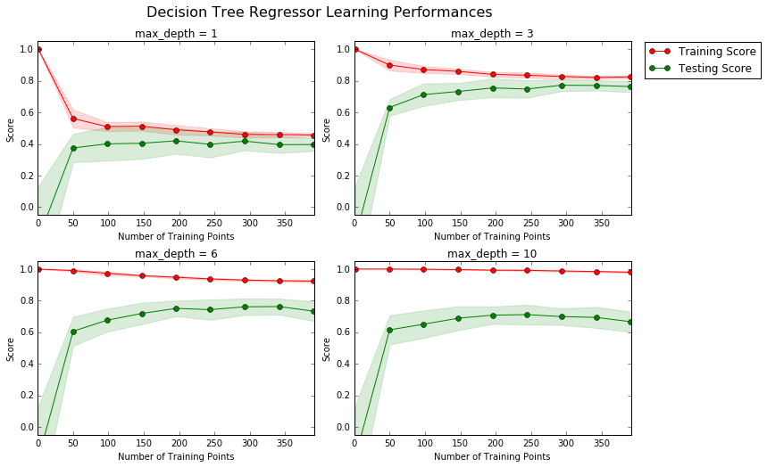

```python
# Produce learning curves for varying training set sizes and maximum depths
vs.ModelLearning(features, prices)
```

### Question 4 - Learning the Data

*Choose one of the graphs above and state the maximum depth for the model. What happens to the score of the training curve as more training points are added? What about the testing curve? Would having more training points benefit the model?*  
**Hint:** Are the learning curves converging to particular scores?

**Answer:** For the model with max_depth = 1 the score of the testing curve initially increases quickly until about 50 training points, but then quickly converges to about 0.4. Increasing the number of training points does little to improve the score.

The training curve also converges to around 0.45, very close to the converged score of the testing curve. This means the model is evaluating training points just as badly as testing points and so adding more training points does not help since it is clear bias is the issue rather than variance. The model is not complex enough to adequately discover the patterns in the data. This makes sense in this case since the decision tree was limited to a depth of just one.

### Complexity Curves

The following code cell produces a graph for a decision tree model that has been trained and validated on the training data using different maximum depths. The graph produces two complexity curves — one for training and one for validation. Similar to the **learning curves**, the shaded regions of both the complexity curves denote the uncertainty in those curves, and the model is scored on both the training and validation sets using the `performance_metric` function.

Run the code cell below and use this graph to answer the following two questions.

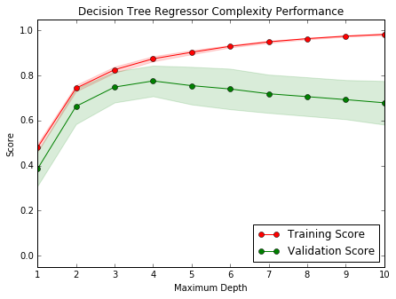

```python
vs.ModelComplexity(X_train, y_train)
```

### Question 5 - Bias-Variance Tradeoff

*When the model is trained with a maximum depth of 1, does the model suffer from high bias or from high variance? How about when the model is trained with a maximum depth of 10? What visual cues in the graph justify your conclusions?*  
**Hint:** How do you know when a model is suffering from high bias or high variance?

**Answer:** When the model is trained with a maximum depth of 1 the situation is the same as I described in my answer to question 4; it is suffering from high bias, not high variance. The training and validation scores are both very similar (and both poor) so adding additional data points will not help. Since the training score is poor we can tell the model is not sufficient to correctly pick out the underlying patterns in the data, so it has high bias.

As for the case when the model is trained with a maximum depth of 10, the training score has massively increased and is now close to the maximum score of 1. The model is much more complicated and is correctly modelling the training data, so we know the problem is not bias anymore. The large gap between the training and validation scores shows us that we now have high variance issue.

### Question 6 - Best-Guess Optimal Model

*Which maximum depth do you think results in a model that best generalizes to unseen data? What intuition lead you to this answer?*

**Answer:** A maximum depth of 4 seems to generalise best to unseen data; it has the highest r2 score of about 0.75. Reducing maximum depth less than 4 seems to increase bias errors, whereas increasing maximum depth above this seems to increase variance errors. The higher maximum depths are probably also overfitting. Thus maximum depth of 4 seems to give best trade off between minimising both bias and variance errors.

## Evaluating Model Performance

In this final section of the project, you will construct a model and make a prediction on the client's feature set using an optimized model from `fit_model`.

### Question 7 - Grid Search

*What is the grid search technique and how it can be applied to optimize a learning algorithm?*

**Answer:** The machine learning algorithms we use have different hyperparameters which control different aspects over exactly how they work. A good example is the max_depth parameter for the Decision Tree algorithm that we used so far in this project which sets an upper bound on the number of levels of hierachy in the tree.

When we want to apply a learning algorithm to a problem we have to set these hyperparameters, but it wont usually be clear exactly what the optimal parameters should be. It can be complicated enough just trying to tune one parameter as we saw so far in this project, but in reality we might want to set 2,3 or even more different parameters. Furthemore changing one parameter will almost certainly change the optimal value for one of the other ones. As the number of hyperparameters increases, the number of options increases exponentially, so we need a systematic way to keep track of and determine the best parameters to use. This is where the grid search technique comes in.

In the grid search technique we tell the algorithm which n parameters we want to tune and a list of potential values for each. It makes a n-dimensional grid of all possible combinations of all parameters and then runs our target machine learning algorithm with each of those combinations, keeping track of the scores/errors obtained by each. It then selects the parameters which created the highest score/lowest error and presents these as the optimal tuning values for the machine learning algorithm.

### Question 8 - Cross-Validation

*What is the k-fold cross-validation training technique? What benefit does this technique provide for grid search when optimizing a model?*  
**Hint:** Much like the reasoning behind having a testing set, what could go wrong with using grid search without a cross-validated set?

**Answer:** As already discussed it is important for us to split the data into training and testing sets. But when we do grid search we need further subdivide the data into training, validation and testing sets. The model is first created with the training set, then hyperparameters are tuned with the validation set and finally the models score evaluated with the testing set. But we have a difficult trade-off to make in determining how much data to allocate to each sub-set. The more data we use for training in theory the better the model we can make. But the more data we use for validation the better we can choose the hyperparameters. And finally the more data used for testing, the better we can evaluate how well the model actually worked. Splitting up the data into too small groups can lead to bad performance and this is especially important if we have only have a small data set to start off with.

Using k-fold cross-validation training technique can help avoid us having to make this difficult decision. We still have to separately set aside a sub-portion of the data for testing, but then k-folds helps us maximise the use of the remaining data to do both training and validation. K-folds splits the remaining data into k equally-sized subsets, or 'folds'. It then trains the model using k-1 of the folds and uses the remaining fold for the validation. It then repeats this process k times, each time using a different fold for the validation and the remaining folds for training. The final reported performance of the model is the average score across all k runs. This increases computational complexity, but means all data is used at some point in both training and validation so maximises both the potential of creating the best possible model and having best hyperparameters. It avoids wasting data which is especially important when the number of samples is small.

If we did grid-search without having a cross-validated set we could end up overfitting the hyperparameters to the testing data rather than correctly modelling the underlying trends.

### Implementation: Fitting a Model

Your final implementation requires that you bring everything together and train a model using the **decision tree algorithm**. To ensure that you are producing an optimized model, you will train the model using the grid search technique to optimize the `'max_depth'` parameter for the decision tree. The `'max_depth'` parameter can be thought of as how many questions the decision tree algorithm is allowed to ask about the data before making a prediction. Decision trees are part of a class of algorithms called *supervised learning algorithms*.

In addition, you will find your implementation is using `ShuffleSplit()` for an alternative form of cross-validation (see the `'cv_sets'` variable). While it is not the K-Fold cross-validation technique you describe in **Question 8**, this type of cross-validation technique is just as useful!. The `ShuffleSplit()` implementation below will create 10 (`'n_iter'`) shuffled sets, and for each shuffle, 20% (`'test_size'`) of the data will be used as the *validation set*. While you're working on your implementation, think about the contrasts and similarities it has to the K-fold cross-validation technique.

For the `fit_model` function in the code cell below, you will need to implement the following:

- Use [`DecisionTreeRegressor`](http://scikit-learn.org/stable/modules/generated/sklearn.tree.DecisionTreeRegressor.html) from `sklearn.tree` to create a decision tree regressor object.
  - Assign this object to the `'regressor'` variable.
- Create a dictionary for `'max_depth'` with the values from 1 to 10, and assign this to the `'params'` variable.
- Use [`make_scorer`](http://scikit-learn.org/stable/modules/generated/sklearn.metrics.make_scorer.html) from `sklearn.metrics` to create a scoring function object.
  - Pass the `performance_metric` function as a parameter to the object.
  - Assign this scoring function to the `'scoring_fnc'` variable.
- Use [`GridSearchCV`](http://scikit-learn.org/0.17/modules/generated/sklearn.grid_search.GridSearchCV.html) from `sklearn.grid_search` to create a grid search object.
  - Pass the variables `'regressor'`, `'params'`, `'scoring_fnc'`, and `'cv_sets'` as parameters to the object.
  - Assign the `GridSearchCV` object to the `'grid'` variable.

```python
# TODO: Import 'make_scorer', 'DecisionTreeRegressor', and 'GridSearchCV'
from sklearn.metrics import make_scorer
from sklearn.tree import DecisionTreeRegressor
from sklearn.grid_search import GridSearchCV

def fit_model(X, y):
    """ Performs grid search over the 'max_depth' parameter for a
        decision tree regressor trained on the input data [X, y]. """

    # Create cross-validation sets from the training data
    cv_sets = ShuffleSplit(X.shape[0], n_iter = 10, test_size = 0.20, random_state = 0)

    # TODO: Create a decision tree regressor object
    regressor = DecisionTreeRegressor()

    # TODO: Create a dictionary for the parameter 'max_depth' with a range from 1 to 10
    params = {'max_depth':(range(1,11))}

    # TODO: Transform 'performance_metric' into a scoring function using 'make_scorer'
    scoring_fnc = make_scorer(performance_metric)

    # TODO: Create the grid search object
    grid = GridSearchCV(estimator = regressor, param_grid = params, scoring = scoring_fnc, cv = cv_sets)

    # Fit the grid search object to the data to compute the optimal model
    grid = grid.fit(X, y)

    # Return the optimal model after fitting the data
    return grid.best_estimator_
```

### Making Predictions

Once a model has been trained on a given set of data, it can now be used to make predictions on new sets of input data. In the case of a *decision tree regressor*, the model has learned *what the best questions to ask about the input data are*, and can respond with a prediction for the **target variable**. You can use these predictions to gain information about data where the value of the target variable is unknown — such as data the model was not trained on.

### Question 9 - Optimal Model

*What maximum depth does the optimal model have? How does this result compare to your guess in **Question 6**?*

Run the code block below to fit the decision tree regressor to the training data and produce an optimal model.

```python
# Fit the training data to the model using grid search
reg = fit_model(X_train, y_train)

# Produce the value for 'max_depth'
print "Parameter 'max_depth' is {} for the optimal model.".format(reg.get_params()['max_depth'])
```

```
Parameter 'max_depth' is 4 for the optimal model.
```

**Answer:** Grid search found that the optimal model has depth of 4. This is the same as my prediction from Question 6!

### Question 10 - Predicting Selling Prices

Imagine that you were a real estate agent in the Boston area looking to use this model to help price homes owned by your clients that they wish to sell. You have collected the following information from three of your clients:

| Feature | Client 1 | Client 2 | Client 3 |
| --- | --- | --- | --- |
| Total number of rooms in home | 5 rooms | 4 rooms | 8 rooms |
| Neighborhood poverty level (as %) | 17% | 32% | 3% |
| Student-teacher ratio of nearby schools | 15-to-1 | 22-to-1 | 12-to-1 |

*What price would you recommend each client sell his/her home at? Do these prices seem reasonable given the values for the respective features?*  
**Hint:** Use the statistics you calculated in the **Data Exploration** section to help justify your response.

Run the code block below to have your optimized model make predictions for each client's home.

```python
# Produce a matrix for client data
client_data = [[5, 17, 15], # Client 1
               [4, 32, 22], # Client 2
               [8, 3, 12]]  # Client 3

# Show predictions
for i, price in enumerate(reg.predict(client_data)):
    print "Predicted selling price for Client {}'s home: ${:,.2f}".format(i+1, price)
```

```
Predicted selling price for Client 1's home: $412,950.00
Predicted selling price for Client 2's home: $234,529.79
Predicted selling price for Client 3's home: $896,962.50
```

**Answer:**

The model predicts that Client 1 should sell for 412,950.00. Client 2 should sell for 234,529.79. Client 3 should sell for 896,962.50.

In the Data Exploration section I predicted that the higher the total number of rooms, the higher the selling price. The predicted results also express this trend; client 3 has most rooms, followed by client 1 and lastly client 2, and the prices also follow this order, with client 3 being most expensive, followed by 1, then 2.

Equally, I predicted that lower neighbourhood poverty level would increase the expected selling price of a home, and again the algorithm predicts the same thing. Client 3 has least poverty, followed by Client 1 and Client 2 and again prices follow this order.

Finally, I predicted that a lower student-teacher ratio would improve selling prices, and this is also suggested by the model. Client 3 has lowest ratio, followed by Client 1 and Client 2, and again prices follow suit.

As for how reasonable the prices are we can see that none are less than the minimum price (105,000) or more than the maximum price (1,024,800). It wouldn't necessarily be unreasonable for the predicted value to be higher or lower than any in the original data set, depending on the features present, but the fact they are within the original range at least suggests the model isn't doing anything really strange or making really big outliers. Furthermore, we can see that all the predictions are within 3 standard deviations from the mean, which again suggests the model isnt making any big outliers.

Based on feedback from first review I also want to get an idea as to how accurate the absolute values are, not just the general trend. To do this, in the cell below I have code that implements K-Nearest Neighbours to check the average selling prices of the 10 houses that most closely represent those of my three clients (in terms of features). This should further confirm how reasonable the results are.

```python
from sklearn.neighbors import KNeighborsRegressor as knn

reg = knn(n_neighbors=10)
reg.fit(features, prices)

for i, price in enumerate(reg.predict(client_data)):
    print "Predicted selling price for Client {}'s home: ${:,.2f}".format(i+1, price)
```

```
Predicted selling price for Client 1's home: $399,420.00
Predicted selling price for Client 2's home: $196,770.00
Predicted selling price for Client 3's home: $870,450.00
```

### Sensitivity

An optimal model is not necessarily a robust model. Sometimes, a model is either too complex or too simple to sufficiently generalize to new data. Sometimes, a model could use a learning algorithm that is not appropriate for the structure of the data given. Other times, the data itself could be too noisy or contain too few samples to allow a model to adequately capture the target variable — i.e., the model is underfitted. Run the code cell below to run the `fit_model` function ten times with different training and testing sets to see how the prediction for a specific client changes with the data it's trained on.

```python
vs.PredictTrials(features, prices, fit_model, client_data)
```

```
Trial 1: $391,183.33
Trial 2: $419,700.00
Trial 3: $415,800.00
Trial 4: $420,622.22
Trial 5: $418,377.27
Trial 6: $411,931.58
Trial 7: $399,663.16
Trial 8: $407,232.00
Trial 9: $351,577.61
Trial 10: $413,700.00

Range in prices: $69,044.61
```

### Question 11 - Applicability

*In a few sentences, discuss whether the constructed model should or should not be used in a real-world setting.*  
**Hint:** Some questions to answering:

- *How relevant today is data that was collected from 1978?*
- *Are the features present in the data sufficient to describe a home?*
- *Is the model robust enough to make consistent predictions?*
- *Would data collected in an urban city like Boston be applicable in a rural city?*

**Answer:** The model we made could in theory be used as a basic starting point to give a rough estimate of prices, however in practice it is probably too basic to be of much real-world use. The data from 1978 might be able to model basic trends that are still relevant today (i.e. more rooms = higher price) but the exact monetary amounts (even accouting for inflation) are not likely to mean anything. I'm not sure how long houses usually last in USA, but in Japan where I live the average house life is less than 30 years, so not many building from 1978 will be around any more so new homes made with modern construction techniques could have different prices. Furthemore in 1983 new regulations were introduced to ensure homes are built more strongly against earthquakes, so it is likely they will be proportionally more expensive than before.

The number of features is small (although as we have seen more is not *necessarily* better); things like the age of the house, type of materials used to construct it and if it has a garden or not (and if so its size) would likely improve the model further. As it stands I expect this model could have too larger bias.

The model would be better if it was made more robust with less variance. Client 1's house is always predicted at roughly 400,000, yet Predict Trials shows there is a range of 69044 across 10 different test/train splits. This is 17% and would make a significant difference to final selling price. Collecting more data could help improve this variance.

The house selling price is a function of the building cost and the cost of land it is built on. Our model makes some reference to underlying land cost based on neighbourhood poverty and student-teacher ratio, but it neglects the fact that land costs more in urban than rural areas. Thus whilst the model may be able to make some generalisations that are applicable in rural areas as well as urban ones, again the exact monetary amounts are not likely to be exactly correct.

> **Note**: Once you have completed all of the code implementations and successfully answered each question above, you may finalize your work by exporting the iPython Notebook as an HTML document. You can do this by using the menu above and navigating to  
> **File -> Download as -> HTML (.html)**. Include the finished document along with this notebook as your submission.